# Homework-5

Waheeb Algabri, Joe Garcia, Lwin Shwe, Mikhail Broomes

## Data Exploration

```
## tibble [12,795 × 15] (S3: tbl_df/tbl/data.frame)
##  $ TARGET            : int [1:12795] 3 3 5 3 4 0 0 4 3 6 ...
##  $ FixedAcidity      : num [1:12795] 3.2 4.5 7.1 5.7 8 11.3 7.7 6.5 14.8 5.5 ...
##  $ VolatileAcidity   : num [1:12795] 1.16 0.16 2.64 0.385 0.33 0.32 0.29 -1.22 0.27 -0.22 ...
##  $ CitricAcid        : num [1:12795] -0.98 -0.81 -0.88 0.04 -1.26 0.59 -0.4 0.34 1.05 0.39 ...
##  $ ResidualSugar     : num [1:12795] 54.2 26.1 14.8 18.8 9.4 ...
##  $ Chlorides         : num [1:12795] -0.567 -0.425 0.037 -0.425 NA 0.556 0.06 0.04 -0.007 -0.277 ...
##  $ FreeSulfurDioxide : num [1:12795] NA 15 214 22 -167 -37 287 523 -213 62 ...
##  $ TotalSulfurDioxide: num [1:12795] 268 -327 142 115 108 15 156 551 NA 180 ...
##  $ Density           : num [1:12795] 0.993 1.028 0.995 0.996 0.995 ...
##  $ pH                : num [1:12795] 3.33 3.38 3.12 2.24 3.12 3.2 3.49 3.2 4.93 3.09 ...
##  $ Sulphates         : num [1:12795] -0.59 0.7 0.48 1.83 1.77 1.29 1.21 NA 0.26 0.75 ...
##  $ Alcohol           : num [1:12795] 9.9 NA 22 6.2 13.7 15.4 10.3 11.6 15 12.6 ...
##  $ LabelAppeal       : int [1:12795] 0 -1 -1 -1 0 0 0 1 0 0 ...
##  $ AcidIndex         : int [1:12795] 8 7 8 6 9 11 8 7 6 8 ...
##  $ STARS             : int [1:12795] 2 3 3 1 2 NA NA 3 NA 4 ...
```

```
## tibble [3,335 × 15] (S3: tbl_df/tbl/data.frame)
##  $ TARGET            : logi [1:3335] NA NA NA NA NA NA ...
##  $ FixedAcidity      : num [1:3335] 5.4 12.4 7.2 6.2 11.4 17.6 15.5 15.9 11.6 3.8 ...
##  $ VolatileAcidity   : num [1:3335] -0.86 0.385 1.75 0.1 0.21 0.04 0.53 1.19 0.32 0.22 ...
##  $ CitricAcid        : num [1:3335] 0.27 -0.76 0.17 1.8 0.28 -1.15 -0.53 1.14 0.55 0.31 ...
##  $ ResidualSugar     : num [1:3335] -10.7 -19.7 -33 1 1.2 1.4 4.6 31.9 -50.9 -7.7 ...
##  $ Chlorides         : num [1:3335] 0.092 1.169 0.065 -0.179 0.038 ...
##  $ FreeSulfurDioxide : num [1:3335] 23 -37 9 104 70 -250 10 115 35 40 ...
##  $ TotalSulfurDioxide: num [1:3335] 398 68 76 89 53 140 17 381 83 129 ...
##  $ Density           : num [1:3335] 0.985 0.99 1.046 0.989 1.029 ...
##  $ pH                : num [1:3335] 5.02 3.37 4.61 3.2 2.54 3.06 3.07 2.99 3.32 4.72 ...
##  $ Sulphates         : num [1:3335] 0.64 1.09 0.68 2.11 -0.07 -0.02 0.75 0.31 2.18 -0.64 ...
##  $ Alcohol           : num [1:3335] 12.3 16 8.55 12.3 4.8 11.4 8.5 11.4 -0.5 10.9 ...
##  $ LabelAppeal       : int [1:3335] -1 0 0 -1 0 1 0 1 0 0 ...
##  $ AcidIndex         : int [1:3335] 6 6 8 8 10 8 12 7 12 7 ...
##  $ STARS             : int [1:3335] NA 2 1 1 NA 4 3 NA NA NA ...
```

The training data set has 12,795 rows and 15 columns: 14 features and 1 response variable, TARGET. The variable `INDEX` is used for observed identification. Twelve of the features describe the chemical properties of wine. The remaining two predictors are rating variables: LabelAppeal refers to the perceived attractiveness of a wine’s product label, while `STARS` is an assessment of wine quality. The output variable, `TARGET`, is a count measure indicating the number of wine case purchases by distributors.

Summary Statistics

| Variable | N | Mean | Std. Dev. | Min | Pctl. 25 | Pctl. 75 | Max |
| --- | --- | --- | --- | --- | --- | --- | --- |
| TARGET | 12795 | 3 | 1.9 | 0 | 2 | 4 | 8 |
| FixedAcidity | 12795 | 7.1 | 6.3 | -18 | 5.2 | 9.5 | 34 |
| VolatileAcidity | 12795 | 0.32 | 0.78 | -2.8 | 0.13 | 0.64 | 3.7 |
| CitricAcid | 12795 | 0.31 | 0.86 | -3.2 | 0.03 | 0.58 | 3.9 |
| ResidualSugar | 12179 | 5.4 | 34 | -128 | -2 | 16 | 141 |
| Chlorides | 12157 | 0.055 | 0.32 | -1.2 | -0.031 | 0.15 | 1.4 |
| FreeSulfurDioxide | 12148 | 31 | 149 | -555 | 0 | 70 | 623 |
| TotalSulfurDioxide | 12113 | 121 | 232 | -823 | 27 | 208 | 1057 |
| Density | 12795 | 0.99 | 0.027 | 0.89 | 0.99 | 1 | 1.1 |
| pH | 12400 | 3.2 | 0.68 | 0.48 | 3 | 3.5 | 6.1 |
| Sulphates | 11585 | 0.53 | 0.93 | -3.1 | 0.28 | 0.86 | 4.2 |
| Alcohol | 12142 | 10 | 3.7 | -4.7 | 9 | 12 | 26 |
| LabelAppeal | 12795 | -0.0091 | 0.89 | -2 | -1 | 1 | 2 |
| AcidIndex | 12795 | 7.8 | 1.3 | 4 | 7 | 8 | 17 |
| STARS | 9436 | 2 | 0.9 | 1 | 1 | 3 | 4 |

### Predictor Variables

Of the 14 feature columns, 8 of them such as `ResidualSugar`, `Chlorides`, `FreeSulfurDioxide`, `TotalSulfurDioxide`, `pH`, `Sulphates`, `Alcohol`, and `STARS` variables contain several missing values. `LabelAppeal`, `AcidIndex`, and `STARS` are discrete variables (i.e categorical) and the rest are continuous. We also noticed that several numerical features representing chemical quantities in the wine exhibit negative minimum values. We hypothesize that the original chemical measurements might have been normalized (potentially via a log transform), allowing for negative values. However, from a physical standpoint, negative concentrations shouldn’t be possible. Despite this, we’ve opted to retain these values as they are.

### Response Variables

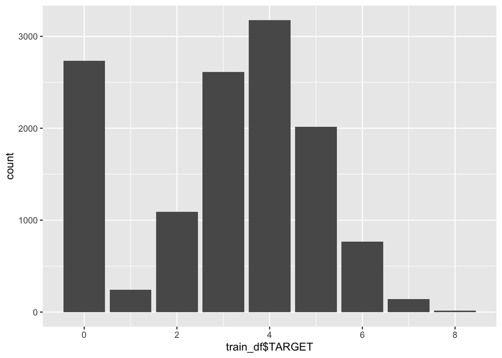

We see that the response variable, `TARGET` value is always between 0 and 8, which makes sense as this is the “Number of Cases of Wine Sold”. In addition, the distribution of wine cases sold, given at least one sale, exhibits symmetry and approximates normality. The target variable, number of cases, is shown below. The data shows a large number of zero values.

### Variables Distributions

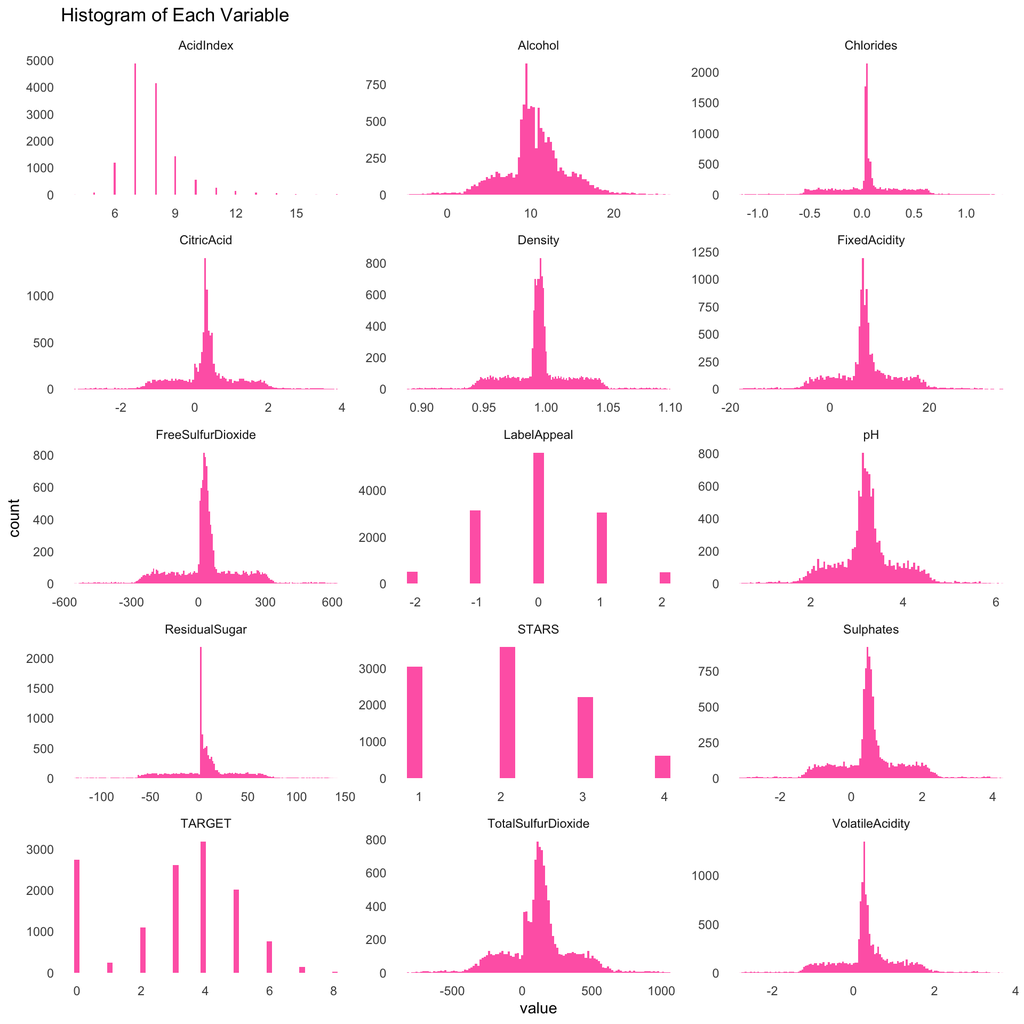

We observe that continuous variables exhibit a somewhat normal steep distribution. However, variables such as `AcidIndex` and `STARS` display right skewness.

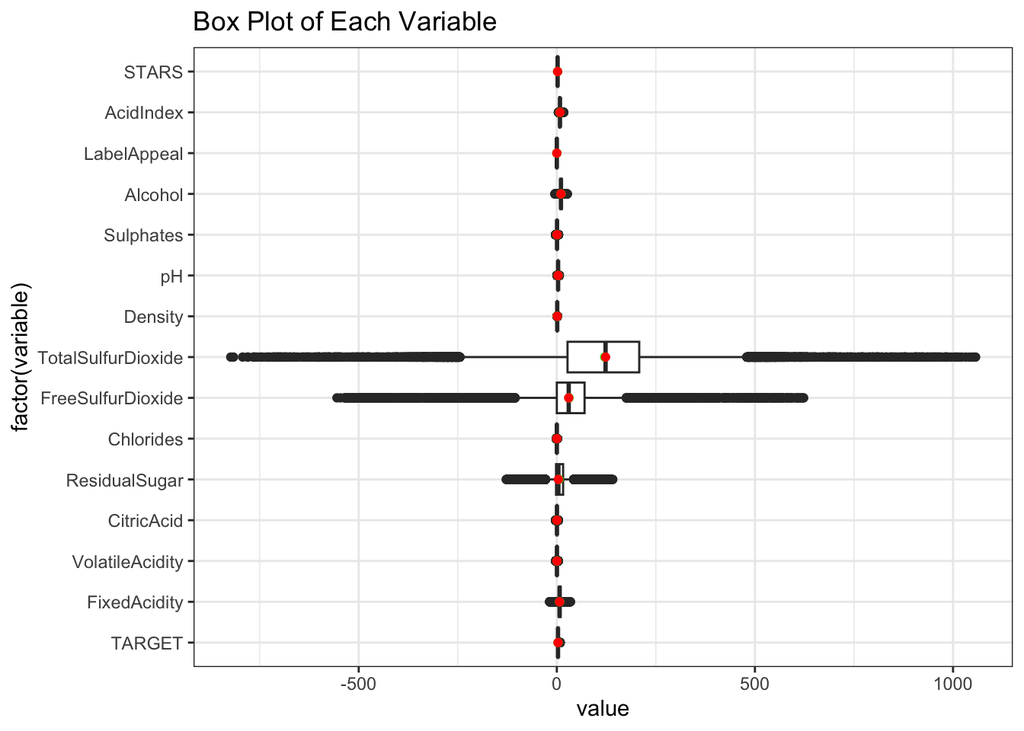

### Relationship Between Categorical and Response Variables

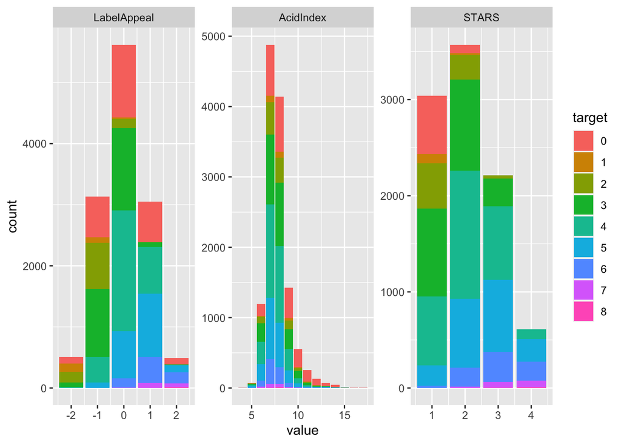

### Multicolinearity

|  | x |
| --- | --- |
| TARGET | 1.0000000 |
| FixedAcidity | -0.0125381 |
| VolatileAcidity | -0.0759979 |
| CitricAcid | 0.0023450 |
| ResidualSugar | 0.0035196 |
| Chlorides | -0.0304301 |
| FreeSulfurDioxide | 0.0226398 |
| TotalSulfurDioxide | 0.0216021 |
| Density | -0.0475989 |
| pH | 0.0002199 |
| Sulphates | -0.0212204 |
| Alcohol | 0.0737771 |
| LabelAppeal | 0.4979465 |
| AcidIndex | -0.1676431 |
| STARS | 0.5546857 |

[figure not shown]

In the correlation table, we can see that `STARS` and `LabelAppeal` are most positively correlated variables with the response variable. Also, we some mild negative correlation between the response variable and `AcidIndex` variable.

## Data Preparation

### Negative Values

The data has some wine quality measures that are negative that should not be. We will simply take the absolute value of these for now. The alternative would be to center by adding the min of each variable. Since we are given little information about the source of this dataset, and why these quality measures are so off, it is difficult to ascertain the best overall approach. For `LabelAppeal`, we will add the min.

### Missing Data

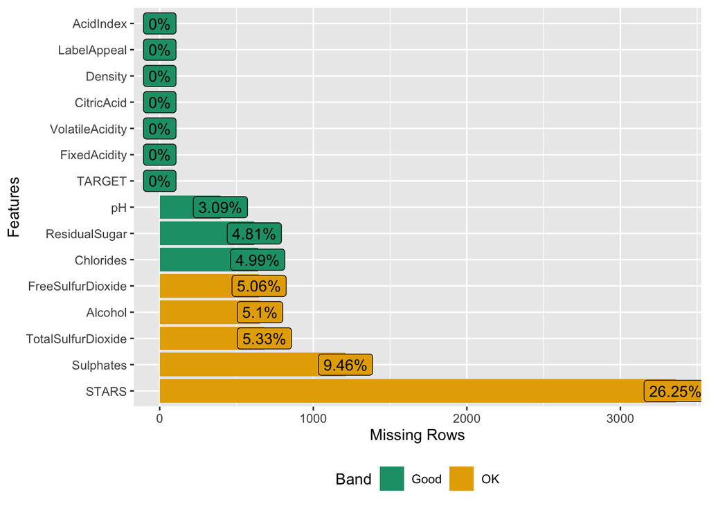

According to the graph, the data set has multiple variables with missing variables. The `STARS` variable has the most NA values. The `Sulphates` variable records missing values in roughly 10% of observations, while the remaining six predictors have missing values ranging from 3% to 5%. These missing values will be imputed later on during the data preparation using the MICE package and random forest prediction method.

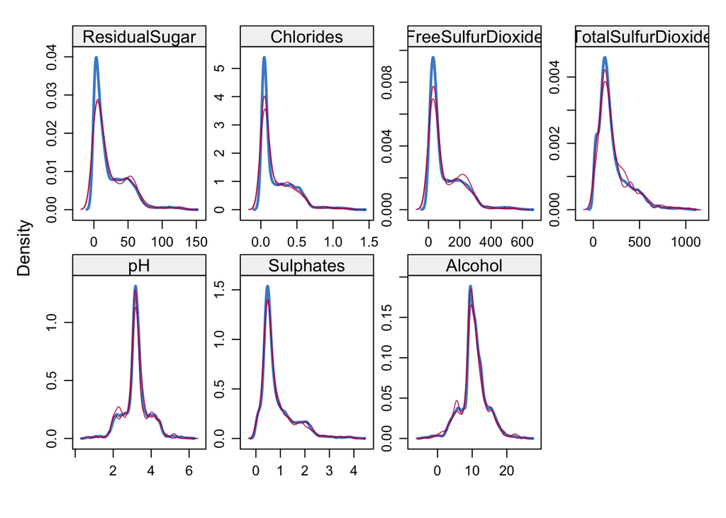

We can see that each of the remaining variables with missing values seem to be MAR, as the mice imputation distributions roughly match the existing. We’ll also run the mice imputation again on both the train and test set. Instead of using it for our models, however, we’ll simplify our run and fill in our data. Finally, after our analysis, we can use it in in our model, we’ll update STARS to become a factor variable.

### Descriptive Summaries and Correlation Review

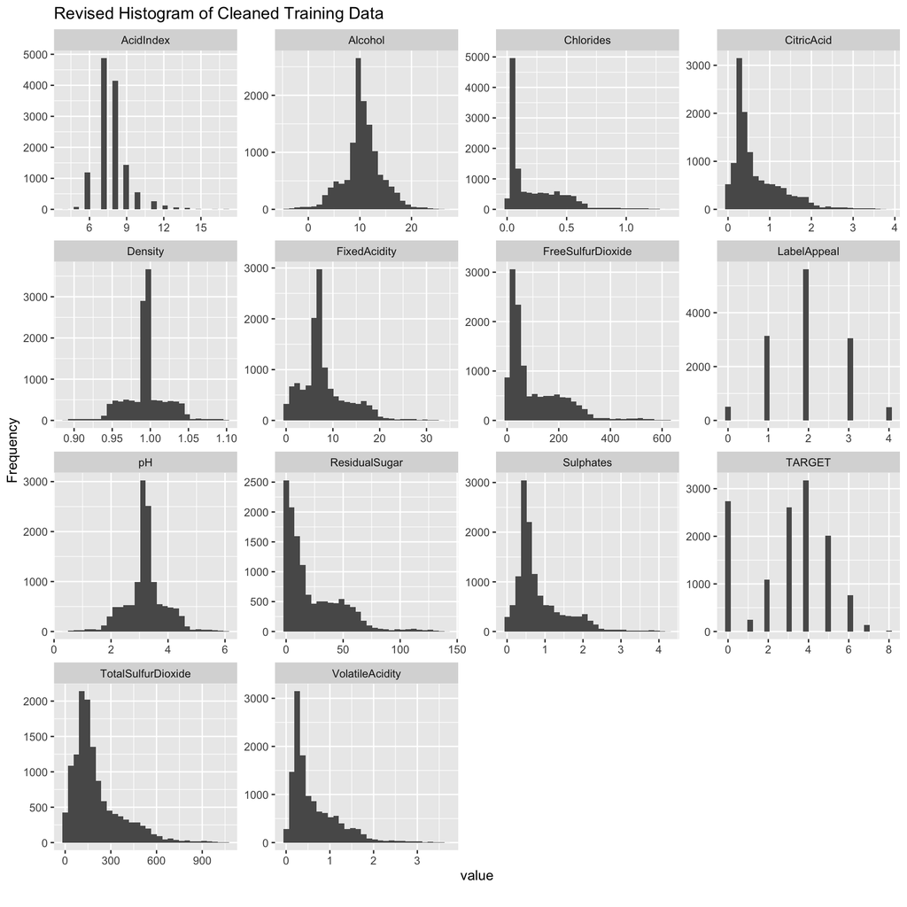

|  | Mean | Std.Dev | Min | Q1 | Median | Q3 | Max | MAD | IQR | CV | Skewness | SE.Skewness | Kurtosis | N.Valid | Pct.Valid |
| --- | --- | --- | --- | --- | --- | --- | --- | --- | --- | --- | --- | --- | --- | --- | --- |
| AcidIndex | 7.7727237 | 1.3239264 | 4.00000 | 7.00000 | 8.00000 | 8.00000 | 17.00000 | 1.4826000 | 1.000000 | 0.1703298 | 1.6484959 | 0.0216523 | 5.1900925 | 12795 | 100 |
| Alcohol | 10.4807704 | 3.7233165 | -4.70000 | 9.00000 | 10.40000 | 12.40000 | 26.50000 | 2.3721600 | 3.400000 | 0.3552522 | -0.0306208 | 0.0216523 | 1.5399928 | 12795 | 100 |
| Chlorides | 0.2227882 | 0.2342173 | 0.00000 | 0.04600 | 0.09900 | 0.36900 | 1.35100 | 0.1008168 | 0.323000 | 1.0513004 | 1.4798442 | 0.0216523 | 2.1837525 | 12795 | 100 |
| CitricAcid | 0.6863150 | 0.6060052 | 0.00000 | 0.28000 | 0.44000 | 0.97000 | 3.86000 | 0.3261720 | 0.690000 | 0.8829841 | 1.6428101 | 0.0216523 | 2.9474433 | 12795 | 100 |
| Density | 0.9942027 | 0.0265376 | 0.88809 | 0.98772 | 0.99449 | 1.00052 | 1.09924 | 0.0093552 | 0.012795 | 0.0266924 | -0.0186938 | 0.0216523 | 1.8999592 | 12795 | 100 |
| FixedAcidity | 8.0632513 | 4.9961186 | 0.00000 | 5.60000 | 7.00000 | 9.80000 | 34.40000 | 2.9652000 | 4.200000 | 0.6196159 | 1.1742806 | 0.0216523 | 1.9666235 | 12795 | 100 |
| FreeSulfurDioxide | 106.2892927 | 108.0521706 | 0.00000 | 28.00000 | 55.00000 | 171.00000 | 623.00000 | 59.3040000 | 143.000000 | 1.0165857 | 1.5351875 | 0.0216523 | 2.4592719 | 12795 | 100 |
| LabelAppeal | 1.9909340 | 0.8910892 | 0.00000 | 1.00000 | 2.00000 | 3.00000 | 4.00000 | 1.4826000 | 2.000000 | 0.4475735 | 0.0084295 | 0.0216523 | -0.2622916 | 12795 | 100 |
| pH | 3.2067104 | 0.6800719 | 0.48000 | 2.95000 | 3.20000 | 3.47000 | 6.13000 | 0.3854760 | 0.515000 | 0.2120777 | 0.0385950 | 0.0216523 | 1.6292482 | 12795 | 100 |
| ResidualSugar | 23.2877061 | 24.8777541 | 0.00000 | 3.60000 | 12.90000 | 38.50000 | 141.15000 | 16.3086000 | 34.900000 | 1.0682784 | 1.4741280 | 0.0216523 | 2.2538118 | 12795 | 100 |
| Sulphates | 0.8460883 | 0.6558266 | 0.00000 | 0.43000 | 0.59000 | 1.10000 | 4.24000 | 0.3261720 | 0.670000 | 0.7751279 | 1.6917630 | 0.0216523 | 3.2294753 | 12795 | 100 |
| TARGET | 3.0290739 | 1.9263682 | 0.00000 | 2.00000 | 3.00000 | 4.00000 | 8.00000 | 1.4826000 | 2.000000 | 0.6359595 | -0.3263010 | 0.0216523 | -0.8772457 | 12795 | 100 |
| TotalSulfurDioxide | 204.9099258 | 163.8645075 | 0.00000 | 100.00000 | 154.00000 | 263.00000 | 1057.00000 | 102.2994000 | 163.000000 | 0.7996904 | 1.6100847 | 0.0216523 | 3.0153943 | 12795 | 100 |
| VolatileAcidity | 0.6410856 | 0.5556141 | 0.00000 | 0.25000 | 0.41000 | 0.91000 | 3.68000 | 0.3261720 | 0.660000 | 0.8666770 | 1.6529782 | 0.0216523 | 3.0833040 | 12795 | 100 |

[figure not shown]

### Split the Sample data Set

With our transformations complete, we can now add these into our `cleaned_train` dataframe and continue on to build our models. To better measure each model performance, we split our data into a training and testing data set. We will train using the first, then measure model performance again the testing hold out set.

```
## [1] "Number of Training Samples:  10238"
```

```
## [1] "Number of Testing Samples:  2557"
```

## Build Models

### Poisson Regression Model 1

In this first model, we include all available features: `FixedAcidity`, `VolatileAcidity`, `CitricAcid`, `ResidualSugar`, `Chlorides`, `FreeSulfurDioxide`, `TotalSulfurDioxide`, `Density`, `pH`, `Sulphates`, `Alcohol`, `LabelAppeal`, `AcidIndex`, `STARS`

```
##
## Call:
## glm(formula = TARGET ~ ., family = poisson, data = trainingData)
##
## Deviance Residuals:
##     Min       1Q   Median       3Q      Max
## -3.2730  -0.6622  -0.0022   0.4590   3.4596
##
## Coefficients:
##                       Estimate  Std. Error z value             Pr(>|z|)
## (Intercept)         0.88401786  0.22058337   4.008            0.0000613 ***
## FixedAcidity       -0.00019300  0.00116712  -0.165             0.868655
## VolatileAcidity    -0.03800614  0.01053001  -3.609             0.000307 ***
## CitricAcid          0.00482117  0.00935375   0.515             0.606255
## ResidualSugar       0.00008185  0.00022848   0.358             0.720174
## Chlorides          -0.04430243  0.02467192  -1.796             0.072548 .
## FreeSulfurDioxide   0.00006365  0.00005342   1.192             0.233451
## TotalSulfurDioxide  0.00008298  0.00003462   2.397             0.016543 *
## Density            -0.38653351  0.21575673  -1.792             0.073209 .
## pH                 -0.00883178  0.00848151  -1.041             0.297737
## Sulphates          -0.00464684  0.00870712  -0.534             0.593561
## Alcohol             0.00307482  0.00153833   1.999             0.045630 *
## LabelAppeal         0.15940496  0.00687464  23.187 < 0.0000000000000002 ***
## AcidIndex          -0.07667561  0.00511881 -14.979 < 0.0000000000000002 ***
## STARS1              0.75937762  0.02186553  34.729 < 0.0000000000000002 ***
## STARS2              1.08626089  0.02032575  53.443 < 0.0000000000000002 ***
## STARS3              1.20920722  0.02137683  56.566 < 0.0000000000000002 ***
## STARS4              1.32798791  0.02736105  48.536 < 0.0000000000000002 ***
## ---
## Signif. codes:  0 '***' 0.001 '**' 0.01 '*' 0.05 '.' 0.1 ' ' 1
##
## (Dispersion parameter for poisson family taken to be 1)
##
##     Null deviance: 18279  on 10237  degrees of freedom
## Residual deviance: 10978  on 10220  degrees of freedom
## AIC: 36572
##
## Number of Fisher Scoring iterations: 6
```

```
##          RMSE      Rsquared           MAE           aic           bic
##     2.5896243     0.5177046     2.2206236 36571.6286867 36701.8381949
```

### Poisson Regression Model 2

In this Model 2, we only include the most predictive features : `VolatileAcidity`, `TotalSulfurDioxide`, `Alcohol`, `LabelAppeal`, `AcidIndex`, `STARS`

```
##
## Call:
## glm(formula = TARGET ~ VolatileAcidity + TotalSulfurDioxide +
##     Alcohol + LabelAppeal + AcidIndex + STARS, family = poisson,
##     data = trainingData)
##
## Deviance Residuals:
##     Min       1Q   Median       3Q      Max
## -3.3026  -0.6633  -0.0009   0.4594   3.4943
##
## Coefficients:
##                       Estimate  Std. Error z value             Pr(>|z|)
## (Intercept)         0.46904729  0.04994358   9.392 < 0.0000000000000002 ***
## VolatileAcidity    -0.03830760  0.01052516  -3.640             0.000273 ***
## TotalSulfurDioxide  0.00008305  0.00003461   2.400             0.016413 *
## Alcohol             0.00314054  0.00153790   2.042             0.041142 *
## LabelAppeal         0.15938001  0.00686767  23.207 < 0.0000000000000002 ***
## AcidIndex          -0.07702508  0.00504447 -15.269 < 0.0000000000000002 ***
## STARS1              0.76093283  0.02185558  34.816 < 0.0000000000000002 ***
## STARS2              1.08797214  0.02031653  53.551 < 0.0000000000000002 ***
## STARS3              1.21122854  0.02136172  56.701 < 0.0000000000000002 ***
## STARS4              1.32905420  0.02735111  48.592 < 0.0000000000000002 ***
## ---
## Signif. codes:  0 '***' 0.001 '**' 0.01 '*' 0.05 '.' 0.1 ' ' 1
##
## (Dispersion parameter for poisson family taken to be 1)
##
##     Null deviance: 18279  on 10237  degrees of freedom
## Residual deviance: 10988  on 10228  degrees of freedom
## AIC: 36566
##
## Number of Fisher Scoring iterations: 6
```

```
##          RMSE      Rsquared           MAE           aic           bic
##     2.5897983     0.5170154     2.2208191 36565.5340896 36637.8727052
```

### Negative Binomial Regression Model 3

Similar to Poisson Model 1, the predictors for the following model are: `FixedAcidity`, `VolatileAcidity`, `CitricAcid`, `ResidualSugar`, `Chlorides`, `FreeSulfurDioxide`, `TotalSulfurDioxide`, `Density`, `pH`, `Sulphates`, `Alcohol`, `LabelAppeal`, `AcidIndex`, `STARS`

```
##
## Call:
## glm.nb(formula = TARGET ~ ., data = trainingData, init.theta = 40727.91209,
##     link = log)
##
## Deviance Residuals:
##     Min       1Q   Median       3Q      Max
## -3.2729  -0.6622  -0.0022   0.4590   3.4595
##
## Coefficients:
##                       Estimate  Std. Error z value             Pr(>|z|)
## (Intercept)         0.88405271  0.22059333   4.008            0.0000613 ***
## FixedAcidity       -0.00019303  0.00116717  -0.165             0.868642
## VolatileAcidity    -0.03800764  0.01053047  -3.609             0.000307 ***
## CitricAcid          0.00482133  0.00935418   0.515             0.606260
## ResidualSugar       0.00008184  0.00022849   0.358             0.720193
## Chlorides          -0.04430344  0.02467302  -1.796             0.072555 .
## FreeSulfurDioxide   0.00006365  0.00005342   1.192             0.233443
## TotalSulfurDioxide  0.00008298  0.00003462   2.397             0.016543 *
## Density            -0.38654219  0.21576653  -1.791             0.073216 .
## pH                 -0.00883271  0.00848189  -1.041             0.297708
## Sulphates          -0.00464712  0.00870751  -0.534             0.593556
## Alcohol             0.00307470  0.00153840   1.999             0.045648 *
## LabelAppeal         0.15940399  0.00687495  23.186 < 0.0000000000000002 ***
## AcidIndex          -0.07667809  0.00511900 -14.979 < 0.0000000000000002 ***
## STARS1              0.75937649  0.02186599  34.729 < 0.0000000000000002 ***
## STARS2              1.08625971  0.02032621  53.441 < 0.0000000000000002 ***
## STARS3              1.20920687  0.02137741  56.565 < 0.0000000000000002 ***
## STARS4              1.32798842  0.02736226  48.534 < 0.0000000000000002 ***
## ---
## Signif. codes:  0 '***' 0.001 '**' 0.01 '*' 0.05 '.' 0.1 ' ' 1
##
## (Dispersion parameter for Negative Binomial(40727.91) family taken to be 1)
##
##     Null deviance: 18278  on 10237  degrees of freedom
## Residual deviance: 10978  on 10220  degrees of freedom
## AIC: 36574
##
## Number of Fisher Scoring iterations: 1
##
##
##               Theta:  40728
##           Std. Err.:  38350
## Warning while fitting theta: iteration limit reached
##
##  2 x log-likelihood:  -36535.96
```

```
##          RMSE      Rsquared           MAE           aic           bic
##     2.5896242     0.5177046     2.2206234 36573.9628866 36711.4062564
```

### Negative Binomial Regression Model 4

Similar to Poisson Model 2, the predictors for the following model are: `VolatileAcidity`, `FreeSulfurDioxide`, `TotalSulfurDioxide`, `Alcohol`, `LabelAppeal`, `AcidIndex`, `STARS`

```
##
## Call:
## glm.nb(formula = TARGET ~ VolatileAcidity + FreeSulfurDioxide +
##     TotalSulfurDioxide + Alcohol + LabelAppeal + AcidIndex +
##     STARS, data = cleaned_train, init.theta = 40659.48234, link = log)
##
## Deviance Residuals:
##     Min       1Q   Median       3Q      Max
## -3.3090  -0.6536  -0.0031   0.4547   3.7836
##
## Coefficients:
##                       Estimate  Std. Error z value             Pr(>|z|)
## (Intercept)         0.47732250  0.04491006  10.628 < 0.0000000000000002 ***
## VolatileAcidity    -0.03706654  0.00939412  -3.946            0.0000796 ***
## FreeSulfurDioxide   0.00005268  0.00004689   1.123              0.26127
## TotalSulfurDioxide  0.00008837  0.00003104   2.847              0.00442 **
## Alcohol             0.00368970  0.00137441   2.685              0.00726 **
## LabelAppeal         0.15942451  0.00612676  26.021 < 0.0000000000000002 ***
## AcidIndex          -0.08028377  0.00449971 -17.842 < 0.0000000000000002 ***
## STARS1              0.77095559  0.01953002  39.475 < 0.0000000000000002 ***
## STARS2              1.09236374  0.01820285  60.011 < 0.0000000000000002 ***
## STARS3              1.21265049  0.01917736  63.233 < 0.0000000000000002 ***
## STARS4              1.32851855  0.02428483  54.706 < 0.0000000000000002 ***
## ---
## Signif. codes:  0 '***' 0.001 '**' 0.01 '*' 0.05 '.' 0.1 ' ' 1
##
## (Dispersion parameter for Negative Binomial(40659.48) family taken to be 1)
##
##     Null deviance: 22860  on 12794  degrees of freedom
## Residual deviance: 13683  on 12784  degrees of freedom
## AIC: 45650
##
## Number of Fisher Scoring iterations: 1
##
##
##               Theta:  40659
##           Std. Err.:  34189
## Warning while fitting theta: iteration limit reached
##
##  2 x log-likelihood:  -45626.25
```

```
##          RMSE      Rsquared           MAE           aic           bic
##     2.5893189     0.5158105     2.2199834 45650.2463626 45739.7280796
```

### Multiple Linear Regression Model 5

The predictors for the following model are: `FixedAcidity`, `VolatileAcidity`, `CitricAcid`, `ResidualSugar`, `Chlorides`, `FreeSulfurDioxide`, `TotalSulfurDioxide`, `Density`, `pH`, `Sulphates`, `Alcohol`, `LabelAppeal`, `AcidIndex`, `STARS`

```
##
## Call:
## lm(formula = TARGET ~ ., data = trainingData)
##
## Residuals:
##     Min      1Q  Median      3Q     Max
## -4.8414 -0.8737  0.0236  0.8555  5.6826
##
## Coefficients:
##                        Estimate   Std. Error t value             Pr(>|t|)
## (Intercept)         3.020068489  0.500891225   6.029         0.0000000017 ***
## FixedAcidity        0.000469154  0.002635703   0.178              0.85873
## VolatileAcidity    -0.112649856  0.023435095  -4.807         0.0000015548 ***
## CitricAcid          0.019109205  0.021413858   0.892              0.37221
## ResidualSugar       0.000007501  0.000521091   0.014              0.98851
## Chlorides          -0.124471650  0.055517825  -2.242              0.02498 *
## FreeSulfurDioxide   0.000204177  0.000121857   1.676              0.09386 .
## TotalSulfurDioxide  0.000249243  0.000079087   3.152              0.00163 **
## Density            -1.156597986  0.492177579  -2.350              0.01879 *
## pH                 -0.018547127  0.019254329  -0.963              0.33543
## Sulphates          -0.010122588  0.019789678  -0.512              0.60901
## Alcohol             0.010995114  0.003491237   3.149              0.00164 **
## LabelAppeal         0.465246728  0.015346756  30.316 < 0.0000000000000002 ***
## AcidIndex          -0.191380479  0.010214692 -18.736 < 0.0000000000000002 ***
## STARS1              1.350459388  0.037032187  36.467 < 0.0000000000000002 ***
## STARS2              2.395624269  0.035846190  66.831 < 0.0000000000000002 ***
## STARS3              2.974936849  0.041397001  71.864 < 0.0000000000000002 ***
## STARS4              3.688404529  0.067342857  54.771 < 0.0000000000000002 ***
## ---
## Signif. codes:  0 '***' 0.001 '**' 0.01 '*' 0.05 '.' 0.1 ' ' 1
##
## Residual standard error: 1.311 on 10220 degrees of freedom
## Multiple R-squared:  0.537,  Adjusted R-squared:  0.5362
## F-statistic: 697.3 on 17 and 10220 DF,  p-value: < 0.00000000000000022
```

```
##         RMSE     Rsquared          MAE          aic          bic
##     1.309785     0.537013     1.031076 34617.903309 34755.346679
```

### Multiple Linear Regression Model 6

For the final Linear Model, we leverage `stepAIC` on our Linear Model 5 to choose the most important features.

```
##
## Call:
## lm(formula = TARGET ~ VolatileAcidity + Chlorides + FreeSulfurDioxide +
##     TotalSulfurDioxide + Density + Alcohol + LabelAppeal + AcidIndex +
##     STARS, data = trainingData)
##
## Residuals:
##     Min      1Q  Median      3Q     Max
## -4.8773 -0.8745  0.0206  0.8552  5.6964
##
## Coefficients:
##                       Estimate  Std. Error t value             Pr(>|t|)
## (Intercept)         2.97476244  0.49647332   5.992        0.00000000215 ***
## VolatileAcidity    -0.11312314  0.02342445  -4.829        0.00000139018 ***
## Chlorides          -0.12555620  0.05549618  -2.262              0.02369 *
## FreeSulfurDioxide   0.00020461  0.00012182   1.680              0.09307 .
## TotalSulfurDioxide  0.00024969  0.00007906   3.158              0.00159 **
## Density            -1.17196189  0.49197148  -2.382              0.01723 *
## Alcohol             0.01103529  0.00348994   3.162              0.00157 **
## LabelAppeal         0.46516486  0.01534023  30.323 < 0.0000000000000002 ***
## AcidIndex          -0.19022043  0.01002596 -18.973 < 0.0000000000000002 ***
## STARS1              1.35114025  0.03701656  36.501 < 0.0000000000000002 ***
## STARS2              2.39648117  0.03582750  66.889 < 0.0000000000000002 ***
## STARS3              2.97643406  0.04137313  71.941 < 0.0000000000000002 ***
## STARS4              3.68969165  0.06731839  54.810 < 0.0000000000000002 ***
## ---
## Signif. codes:  0 '***' 0.001 '**' 0.01 '*' 0.05 '.' 0.1 ' ' 1
##
## Residual standard error: 1.311 on 10225 degrees of freedom
## Multiple R-squared:  0.5369, Adjusted R-squared:  0.5364
## F-statistic:   988 on 12 and 10225 DF,  p-value: < 0.00000000000000022
```

```
##         RMSE     Rsquared          MAE          aic          bic
##     1.309912     0.536923     1.030963 34609.892810 34711.166872
```

## Select Models

|  | RMSE | Rsquared | MAE | aic | bic |
| --- | --- | --- | --- | --- | --- |
| Poission_Evaluate1 | 2.589624 | 0.5177046 | 2.220624 | 36571.63 | 36701.84 |
| Poission_Evaluate2 | 2.589798 | 0.5170154 | 2.220819 | 36565.53 | 36637.87 |
| Negative_Binomial_eval3 | 2.589624 | 0.5177046 | 2.220623 | 36573.96 | 36711.41 |
| Negative_Binomial_eval4 | 2.589319 | 0.5158105 | 2.219983 | 45650.25 | 45739.73 |
| Linear_Regression_eval5 | 1.309785 | 0.5370130 | 1.031076 | 34617.90 | 34755.35 |
| Linear_Regression_eval6 | 1.309913 | 0.5369230 | 1.030963 | 34609.89 | 34711.17 |

This table summarizes the **RMSE**, **RSQUARED**, **MAE**, **AIC** and **BIC** for all SIX models. The Linear regressions (**Linear Model 5** and **Linear Model 6**) had the overall best performance based on **RMSE** and **RSQUARED**; as well as **Linear Model 6** had the best performance based on **AIC** and **BIC**.

### Prediction

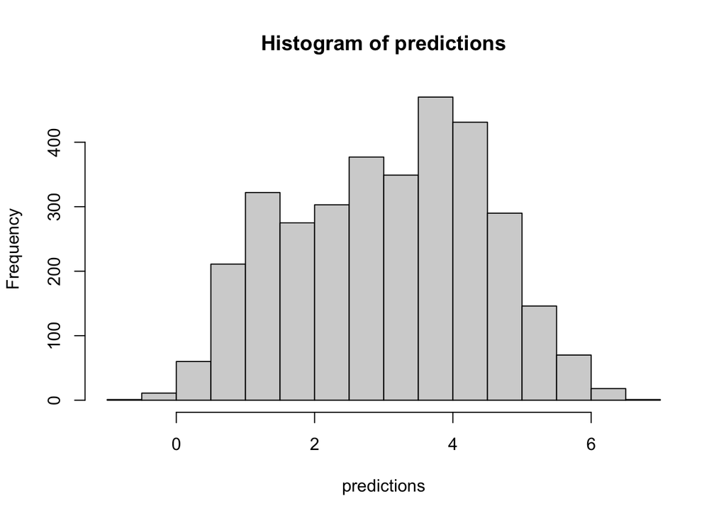

```
##   FixedAcidity VolatileAcidity CitricAcid ResidualSugar Chlorides
## 1          5.4           0.860       0.27          10.7     0.092
## 2         12.4           0.385       0.76          19.7     1.169
## 3          7.2           1.750       0.17          33.0     0.065
## 4          6.2           0.100       1.80           1.0     0.179
## 5         11.4           0.210       0.28           1.2     0.038
## 6         17.6           0.040       1.15           1.4     0.535
##   FreeSulfurDioxide TotalSulfurDioxide Density   pH Sulphates Alcohol
## 1                23                398 0.98527 5.02      0.64   12.30
## 2                37                 68 0.99048 3.37      1.09   16.00
## 3                 9                 76 1.04641 4.61      0.68    8.55
## 4               104                 89 0.98877 3.20      2.11   12.30
## 5                70                 53 1.02899 2.54      0.07    4.80
## 6               250                140 0.95028 3.06      0.02   11.40
##   LabelAppeal AcidIndex STARS    TARGET
## 1           1         6     0 1.2748842
## 2           2         6     2 4.0102323
## 3           2         8     1 2.4171591
## 4           1         8     1 2.2559522
## 5           2        10     0 0.8489494
## 6           3         8     4 5.5647071
```

The predicted file is uploaded to Github: https://github.com/waheeb123/Data-621/blob/main/Homeworks/Homework%205/DATA621_HW5_Predictions.csv